# 4. Índices Espectrales

En esta clase veremos los conceptos básicos de índices espectrales.

## ¿Qué es un índice espectral y cómo se calcula?

Por definición, un **índice espectral** es una operación aritmética, que se calcula para cada pixel, utilizando las bandas de reflectancia espectral de dos o más longitudes de onda.

De este modo pasamos de una imágen multibanda en reflectancias a una imágen monobanda sin dimensiones:

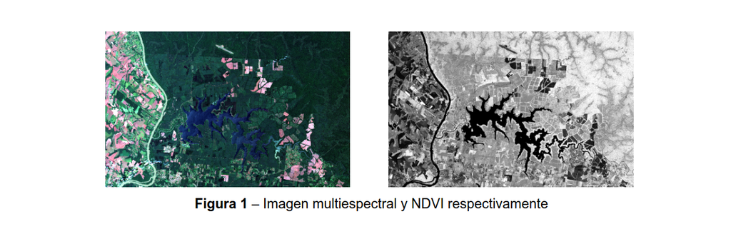

Los índices nos permiten relacionar parámetros biofísicos de la superficie como cobertura, productividad primaria neta o contenido de clorofíla en plantas con posición de algunos minerales en rocas o estimación de superficies quemadas por incendios.

Es decir, nosotros podemos inferir a través de un índice, determinadas variables biofísicas.

### Clasificación

Los índices pueden clasificarse en función del tipo de cobertura que se quiere estudiar:

- Vegetación
- Suelo
- Cuerpos de agua

## Indices de Vegetación

¿Cómo se construye entonces un índice espectral? Partimos de la base de la firma espectral. Veamos un ejemplo:

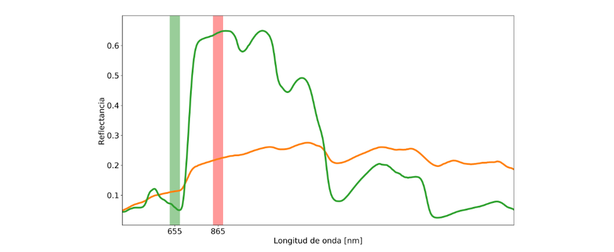

En este caso tenemos la firma espectral de la vegetación (en verde) con su clásico pico de reflectancia en el verde (560 nm), su valle de absorción en el rojo (655 nm) y, el pico más característico de la vegetación saludable en el infrarrojo cercano (865 nm).

Si observamos bien, entre el rojo y el infrarrojo cercano se produce un salto, y para esta firma espectral, tenemos dos bandas que pueden cubrir ese salto: una banda a 655 nm y otra a 865 nm.

En la siguiente imágen tenemos la variación de la firma espectral según el porcentaje de cobertura de la vegetación: a mayor cobertura de la vegetación vamos a tener mayor reflectancia en el infrarrojo y mayor absorción en el rojo.

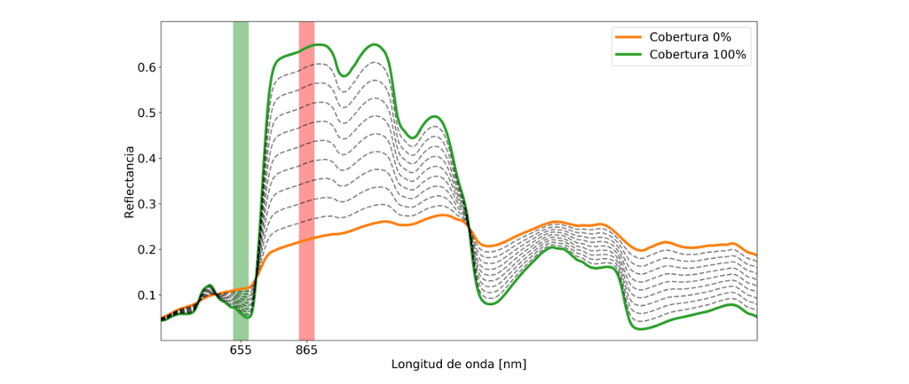

A medida que la cobertura va disminuyendo, también lo hace la reflectancia en el infrarrojo cercano y va aumentando levemente en el rojo.

Entonces, construimos el salto entre el NIR y el Red. Si podemos cuantificar ese salto, podemos entonces obtener un estimador de la cobertura de la vegetación. Una forma sencilla de hacer esto es con un *cociente simple* o *simple ratio*.

Supongamos que tenemos los siguientes valores de infrarrojo cercano $\rho_{nir}$ y rojo $\rho_{red}$:

$$ \rho_{nir}=0.65\\ \rho_{red}=0.05 $$

Que sería un ejemplo de cobertura al ciento por ciento.

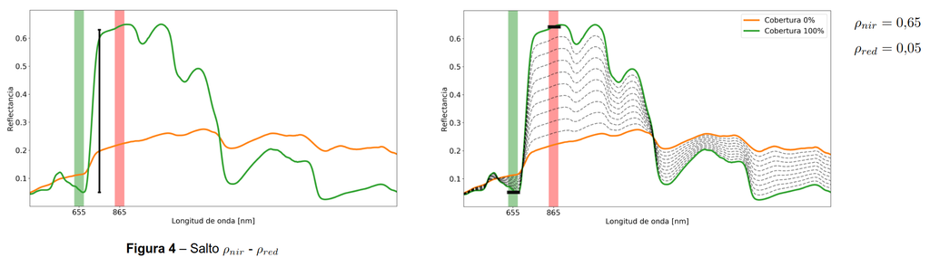

En ese caso, el cociente entre el NIR y el Red sería:

$$ SimpleRatio(SR)=\frac{\rho_{nir}}{\rho_{red}}=13 $$

Este es un número el cual es difícil de comparar, ya que desconocemos el rango en el cual el valor del cociente se mueve, es decir, no tenemos una cota superior y una inferior. Una forma de superar esta reestricción es usar el NDVI que vemos a continuación.

### Normalized Difference Vegetation Index (NDVI)

Definimos al NDVI como:

$$ \text{NDVI}=\frac{\rho_{nir}-\rho_{red}}{\rho_{nir}+\rho_{red}} $$

Con $\rho_{nir}$ y $\rho_{red}$ las reflectancias en el infrarrojo cercano y el rojo, respectivamente.

Al estar normalizado, el NVDI oscilará entre el -1 y el 1. De este modo conoceremos los valores inferiores y superiores y podremos comparar distintos valores entre diferentes ambientes.

### Relación con variable biofísicas

Ahora bien, también nos interesa conocer cuál es la relación del NDVI con las variables biofísicas que mencionamos antes, por ejemplo, con la productividad primaria neta o la cobertura de la vegetación.

Veamos un ejemplo. En el siguiente gráfico observamos que **hay una relación entre el NDVI y la biomasa** medida en gramos por metro cuadrado.

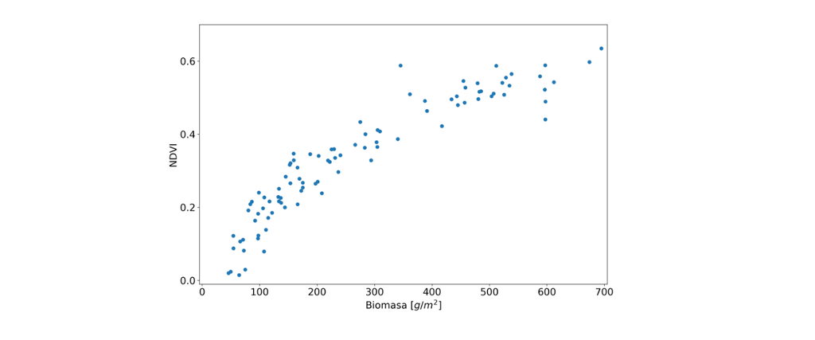

Es decir, en cada punto lo que se hace es recolectar toda la vegetación que hay en un métro cuadrado y pesarla, y en ese mismo punto se estima el valor de NDVI. De modo que se colectan una cantidad de variaciones de biomasa y se mide el NDVI para tener un amplio rango y visualizar bien el comportamiento de toda la variable en el rango.

Si observamos el gráfico vemos que la curva no tiene un comportamiento estrictamente lineal, vemos un cambio en la pendiente en el orden de los 250 g/m² en el cual el NDVI ya no responde de manera tan directa al aumento de la biomasa.

Esto significa que de algún modo, el índice empieza a saturar, es decir, a no resolver esos aumentos. Podría decirse entonces que el índice presenta algunas restricciones. Por ejemplo, como vimos, **satura cuando el canopeo es muy denso**, es decir, cuando hay mucha densidad de vegetación el índice ya no responde a aumentos de la vegetación.

Por otro lado, **la reflectancia del suelo puede afectar** este índice, es decir, en el caso contrario donde hay menor cantidad de vegetación y mayor cantidad de suelo sin cobertura esta reflectancia puede hacer que se subestime el valor de biomasa.

### Soil Adjusted Vegetation Index (SAVI)

Similar al NDVI, el **Soil Adjusted Vegetation Index** o **SAVI** también da cuenta de la cobertura de la vegetación o de la biomasa. Pero, en este caso, añade un coeficiente $L$ que tiene en cuenta la *reflectancia del suelo*.

$$ \rho = \frac{\rho_{nir}-\rho_{red}}{\rho_{nir}+\rho_{red}+L}\cdot(1+L) $$

con $\rho_{nir},\rho_{red}$ las reflectancias en el infrarrojo cercano y el rojo, respectivamente.

El coeficiente $L$ se estima de manera empírica, por lo tanto, es difícil saber de antemano qué valor puede utilizar para cada imágen. El consenso científico da cuenta de que valores de $0.5$ funcionan en la gran mayoria de los casos.

### Normalized Difference Water Index (NDWI)

Tanto el NDVI como el SAVI son estimadores de cobertura y la biomasa de la vegetación. Sin embargo, hay índices como el *NDWI* que estiman el contenido de humedad en las hojas y el canopeo en general.

El **NDWI** o **Normalized Difference Water Index** se calcula como sigue:

$$ NDWI=\frac{\rho_{nir}-\rho_{swir1}}{\rho_{nir}+\rho_{swir1}} $$

con $\rho_{nir},\rho_{swir1}$ las reflectancias en el infrarrojo cercano e infrarrojo de onda corta 1, respectivamente.

De modo que la vegetación con mayor contenido de agua tendrá valores de reflectancia menores en el infrarrojo de onda corta 1, por lo tanto este valor será inferior y dará como resultado valores de NDWI superiores, es decir, con mayor contenido de agua en el canopeo.

Hay que tener en cuenta que el NDWI es de escasa utilidad para la cuantificación de humedad en el suelo sin cobertura vegetal dada la escasa penetrancia que tienen los sistemas ópticos en los suelos.

## Indice de Severidad de Incendios

Otro aspecto interesante de los indices es que pueden servir también como herramientas de monitoreo e impacto ambiental.

Un ejemplo es el índice de severidad de incendios o **Normalized Burn Ratio**. Este índice se construye también a partir de la firma espectral pero, interpretando la variación de la misma.

Definimos el NBR como

$$ NBR=\frac{\rho_{nir}-\rho_{swir2}}{\rho_{nir}+\rho_{swir2}} $$

con $\rho_{nir},\rho_{swir2}$ las reflectancias en el infrarrojo cercano y el infrarrojo de onda corta 2 respectivamente.

De ese modo, los valores muy altos de infrarrojo de onda corta 2 van a hacer que este término sea negativ y por lo tanto el NBR va a tener valores negativos a medida que el incendio sea más severo.

En el siguiente gráfico vemos dos firmas de vegetación: una de vegetación sana y otra de vegetación quemada sometida a un incendio:

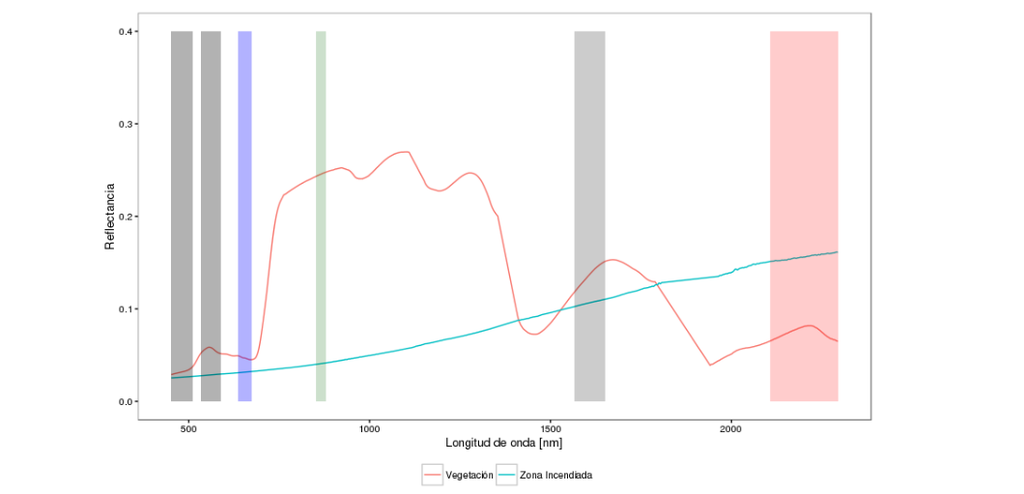

Vemos que la vegetación sana tiene su pico en el infrarrojo cercano, su valle de absorción en el rojo y los dos picos en el infrarrojo de onda corta 1 y 2 respectivamente.

En tanto que en la vegetación quemada, ese patrón se invierte, observando un descenso marcado en el infrarrojo cercano y un aumento marcado también en el infrrarojo de onda corta 2. Es decir, **al quemarse biomasa se invierte el salto SWIR-NIR**.

Sin embargo, en algunos casos, se requiere comparar dos imágenes, una pre y post incendio. Esto ocurre en lugares donde la vegetación es mas escasa y la reflectancia del suelo tiene mayor incidencia.

## Índices Espectrales: Geología

Hasta ahora vimos diferentes formas de cuantificar la vegetación en la superficie terrestre, sin embargo, algunas ramas de la geología, la agronomía o incluso la arqueología, utilizan frecuentemente índices espectrales útiles en caracterizar rocas y suelos. Veamos dos ejemplos.

### Clay Minerals Ratio (CMR)

En el siguiente gráfico, observamos la firma espectral de un mineral arcilloso como la caolinita, que tiene un pico de reflectancia en el infrarrojo de onda corta 1 y un valle de absorción em el infrarrojo de onda corta 2.

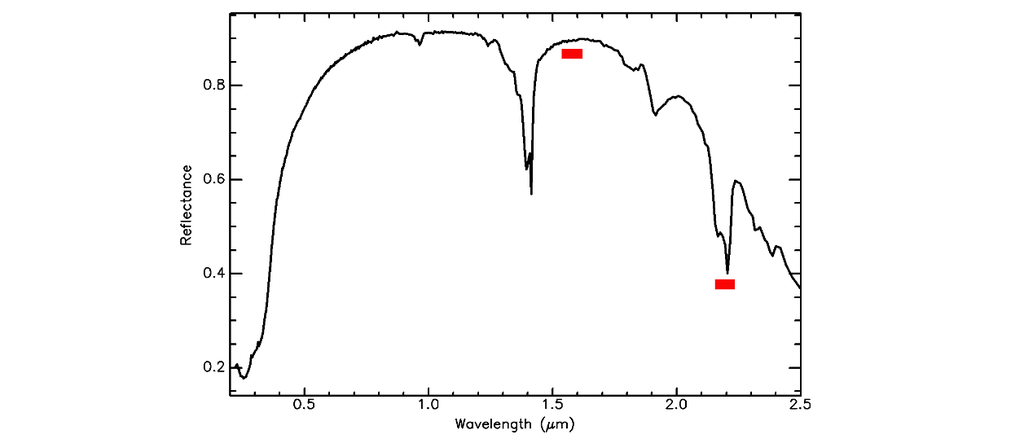

Por lo tanto, se puede construir un cociente entre el infrarrojo de onda corta 1 y el de onda corta 2, este cociente se denomina **Clay Minerals Ratio** o **CMR**, el cual se define como

$$ CMR=\frac{\rho_{swir1}}{\rho_{swir2}} $$

con $\rho_{swir1},\rho{swir2}$ las reflectancias en el infrarrojo de onda corta 1 y el infrarrojo de onda corta 2.

Este índice resalta las rocas alteradas hidrotermalmente que contienen arcilla y alunita.

### Iron Oxide Ratio (IOR)

En el siguiente gráfico observamos la firma espectral de un mineral ferroso como la goethita el cual tiene un pico de reflectancia en el rojo y un valle de absorción en el azul.

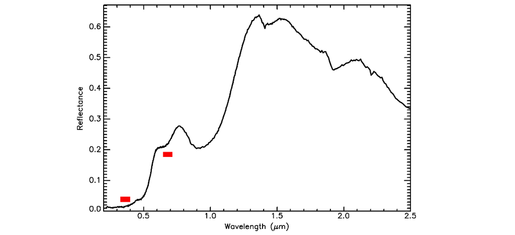

Por lo tanto, se puede construir un cociente entre el rojo y el azul. Este cociente se denomina **Iron Oxide Ratio** o **IOR**:

$$ IOR=\frac{\rho_{red}}{\rho_{blue}} $$

con $\rho_{red},\rho_{blue}$ las reflectancias del rojo y el azul.

La presencia de filosilicatos portadores de limonita la alteración del óxido de hierro limonítico provocan una absorción en la banda azul y reflectancia en la banda roja. Esto hace que las áreas con fuerte alteración del hierro tengan valores más altos en este cociente.

## Conclusiones

- Los índices espectrales son una muy buena herramienta para inferir variables biofísicas a partir de sensores remotos.
- Nos permite ahorrar tiempo, dinero y nos permite cubrir áreas mucho más grandes de las que haríamos midiendo esas variables en el terreno.
- Por supuesto, los indices tienen varias restricciones: las variables biofísicas no ajustan exactamente a los índices y son solamente una aproximación de esa variable.
- También se debe tener en cuenta el contexto: si aplicamos un determinado índice en un lugar el cual no está preparado, nos puede dar información erronea y su mala interpretación puede llevar a tomar decisiones incorrectas.